# Meta-analytic-predictive approach for variances

Tobias Mütze

2017-03-17

The package `varmap` provides functions for the meta-analytic-predictive (MAP) approach for variances of a normally distributed endpoint. In detail, the package `varmap` includes a function for a random-effects meta-analysis of historical variances using Bayesian hierarchical model which then also generates random number from the MAP prior of the variance of a new clinical trials. To approximate the MAP prior of the variance by a mixture of conjugate priors, a function fitting to EM algorithm to a sample is included. More information on the MAP approach itself can be found in Neuenschwander et al. (2010) and in Schmidli et al. (2014). The MAP approach for variances was introduced by Schmidli et al. (2016). This document provides a worked-out example for applying the MAP approach for variances.

# 1 Brief introduction into the MAP approach for variances

In the following a brief introduction into the MAP approach for variances is given. A similar introduction is also given by Mütze et al. (2017). We denote the sample variances observed in historical clinical trials by $\hat{\sigma}^2_{j}$, $j=1,\ldots, J$. The respective degrees of freedom observed in trial $j$ is denoted by $\nu_j$. Moreover, let $\sigma_{j}^{2}$ be the unknown true variance in the historical trial $j=1,\ldots, J$. The assumption that the endpoint of interest in the historical clinical trials follows normal distribution motivates our choice to model the sample variance $\hat{\sigma}^2_{j}$ as a strechted $\chi^2$-distribution, i.e.
$$\begin{align*}
\frac{\nu_j}{\sigma_j^2}\hat{\sigma}_{j}^{2} \Big| \sigma_j^2 \sim \chi_{\nu_j}^2.
\end{align*}$$
This stretched $\chi^2$-distribution can also be written a Gamma distribution
$$\begin{align*}
\hat{\sigma}^2_{j} \big| \sigma_j^2 \sim
\operatorname{Gamma}\left(0.5\nu_j, 0.5\frac{\nu_j}{\sigma_j^2} \right).
\end{align*}$$
Here, we choose the parametrization of a Gamma distribution with shape parameter $a$ and rate parameter $b$, $\operatorname{Gamma}(a,b)$, such that the mean and the variance are given by $a/b$ and $a/b^2$, respectively. To goal is to obtain a MAP prior for the variance $\sigma^2_{new}$ of a to be planned clinical trial based on the variances observed in the historical clinical trials, that is the distribution
$$\begin{align*}
\sigma^{2}_{new} | \hat{\sigma}^2_{1}, \ldots, \hat{\sigma}^2_{J}.
\end{align*}$$
Thereto, a random effect meta-analysis using a Bayesian hierarchical model will be performed. We assume that the variance of the new clinical trial and the true unkown variance of the historical clinical trials follow the same distribution. Let the log-transformed variances $\theta_{new}=\log(\sigma^2_{new}), \theta_{1}=\log(\sigma^2_{1}), \ldots, \theta_{J}=\log(\sigma^2_{J})$ follow a normal distribution, that is
$$\begin{align*}
\theta_{new}, \theta_{1}, \ldots, \theta_{J} \sim
\mathcal{N}\left(\mu, \tau^2\right).
\end{align*}$$
As prior distributions for the mean $\mu$ are normal distribution is recommended,
$$\begin{align*}
\mu \sim \mathcal{N}(\lambda, \sigma_{\mu}^2).
\end{align*}$$
A half-normal distribution has been recommended for the between-trial standad deviation $\tau$,
$$\begin{align*}
\tau \sim \mathcal{N}_{+}(0, \kappa^2).
\end{align*}$$

The posterior density $p(\mu,\tau,\theta_{new}|\hat{\sigma}_{1}^{2}, \ldots, \hat{\sigma}_{J}^{2})$ has not closed form expression but respective random number can be obtained by Markov chain Monte Carlo (MCMC) computations. By transforming the random numbers of the log-variance $\theta_{new}$, a random sample for the posterior predictive distribution, which is referred to as MAP prior, of the variance $\sigma^{2}_{new}$ can be obtained.

## 1.1 Approximating the MAP prior

For theoretical considerations an analytical expression of the MAP prior is generally preferred over a random sample. As shown by Dalal et al. (1983), prior distributions can be approximated by mixtures of conjugate priors. For this purpose, the R package `varmap` contains the function `fit_gammamix` which fits a mixture of Gamma distribution to a sample using the EM algorithm proposed by Almhana et al. (2006). However, for a normal likelihood, the Gamma distribution is not a conjugate prior for the variance $\sigma^2$ but for the precision $\omega = 1/\sigma^2$. Let $L$ be the number of mixture components used when fitting the mixture of Gamma distribution
$$\begin{align*}
\sum_{l=1}^{L}w_{l}\operatorname{Gamma}(a_{l}, b_{l}).
\end{align*}$$

to the MAP prior for the precision $\omega$. The variance is the reciprocal of the precision and the reciprocal of a mixture of Gamma distribution follows a mixture of inverse Gamma distributions. Thus, the MAP prior for the variance $\sigma^2$ can be approximated by mixture of inverse Gamma distributions with the weights $w_l$, shape parameters $a_l$, and rate parameters $b_l$. The inverse Gamma distribution $\operatorname{InvGamma}(a,b)$ is parameterized such that mean and variance are given by $b/(a-1)$ and variance $b^2/((a-1)^2(a-2))$.

# 2 Example

## 2.1 The dataset

```r
library(varmap)
data(varianceSPB)
```

```r
knitr::kable(varianceSPB, caption = "Sample variance of historical clinical trials", row.names = TRUE)
```

Sample variance of historical clinical trials

[output not shown]

## 2.2 Meta-analysis for variances

```r
out <- varmeta(sample_var = varianceHAMD$sample_var, degf = varianceHAMD$degf, mu_mean = 3, n.iter = 10000)
```

The function `varmeta` returns an `mcmc.list` object with the MAP prior of the variance $\sigma^2_{new}$ stored under the name `map_variance`. A histogram of the random samples for the MAP prior of the variance are shown in the next figure.

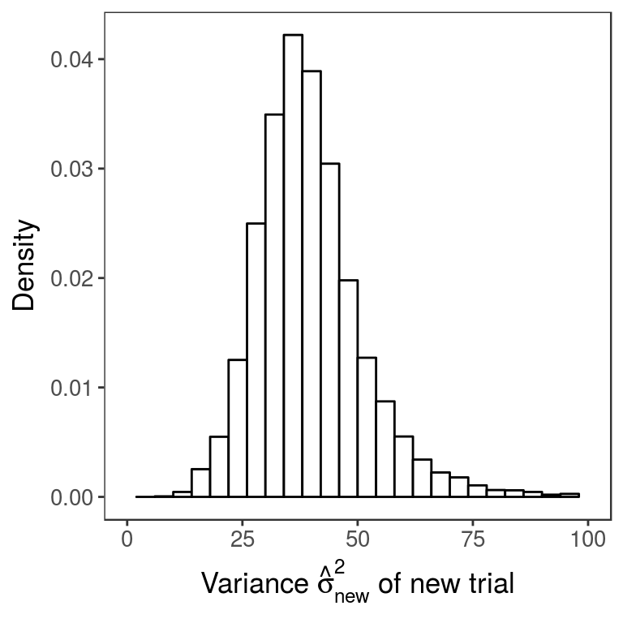

Histogram of MAP prior for variance

## 2.3 Approximation by a mixture of conjugate priors

As mentioned above, working with a set of random numbers from the MAP prior for the variance $\sigma^2_{new}$ is often not handy in practice. However, prior distributions can be approximated by mixtures of conjugate priors. Here, the focus is on approximating the prior for the precision $\omega = 1/\sigma^2$ from which an approximation of the prior for the variance $\sigma^2$ is obtained. The conjugate prior for the precision is a Gamma distribution. Therefore, the R package `varmap` contains the function `fit_gammamix` which fits a mixture of Gamma distributions to a data set. The function `fit_gammamix` has four arguments. The argument `x` must be the vector containing the sample to which the mixture of Gamma distributions is fitted and `k` determines the number of mixture components. The maximum number of iterations, which has a default value of 2500, can be set through the argument `max_iter` and the stopping criteria, which defaults to $10^{-4}$, can be changed using the argument `tol`. The next chunk shows how a mixture of Gamma distributions is fitted to the MAP prior of the precision and the respective output.

```r
fit_out <- fit_gammamix(x = 1/map_variance, k = 2)
fit_out
```

```
## $w
## [1] 0.2564777 0.7435223
##
## $rate
## [1] 192.6781 767.6466
##
## $shape
## [1]  5.988755 20.051624
##
## $loglikeli
## [1] 34640.8
##
## $iter
## [1] 1171
```

The function `fit_gammamix` returns a list with the weights, the rate parameters, and the shape parameters of the mixture of Gamma distributions. The output list also contains the value of the log-likelihood function for estimated parameters and the iteration count at which the algorithm converged. The next figure shows the histogram of the random number from the MAP prior as well as the estimated density of the mixture of Gamma distributions.

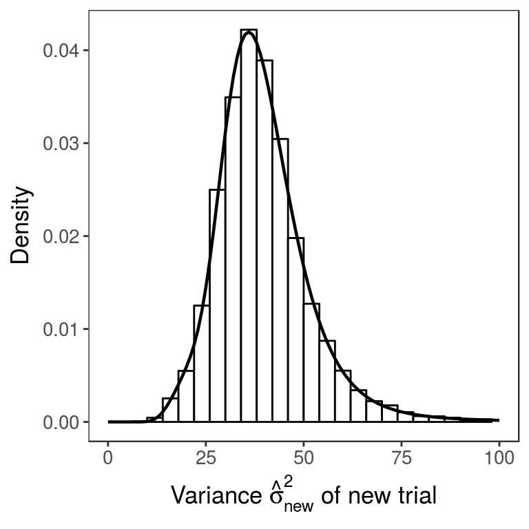

As it can be seen in the last figure, the fitted mixture distributon describes the random sample well. A less heuristical approach to assessing the fit, in particular with respect to the number of mixture components, is to compare the AIC for various fits.

# 3 References

- Almhana J, Liu Z, Choulakian V, McGorman R. A recursive algorithm for gamma mixture models. IEEE International Conference on Communications. 2006 1:197-202.
- Dalal SR, Hall WJ. Approximating priors by mixtures of natural conjugate priors. Journal of the Royal Statistical Society. Series B (Methodological). 1983 1:278-286.
- Neuenschwander B, Capkun-Niggli G, Branson M, Spiegelhalter DJ. Summarizing historical information on controls in clinical trials. Clinical Trials. 2010 7:5-18.
- Schmidli H, Gsteiger S, Roychoudhury S, O’Hagan A, Spiegelhalter D, Neuenschwander B. Robust meta‐analytic‐predictive priors in clinical trials with historical control information. Biometrics. 2014 70:1023-1032.
- Schmidli H, Neuenschwander B, Friede T. Meta-analytic-predictive use of historical variance data for the design and analysis of clinical trials. Computational Statistics & Data Analysis. 2016.
- Mütze T, Schmidli H, Friede T. Nuisance parameter based sample size re-estimation incorporating prior information. Submitted. 2017.